### APPRENTISSAGE NON SUPERVISEE

## ———————————————————–

**LE JEU DE DONNEES**

- On considere un jeu de données concernant n = 101 victimes d’infactus du myocarde réparties en K = 2 groupes : le groupe G1 des victimes décédées (n1 = 51) et le groupe G2 des victimes qui survivent (n2 = 50). On veut construire un score de risque de décés applicable à une nouvelle victime.
- Pour chaque victime, 7 variables cliniques ont été mesurées :
  - FRCAR : fréquence cardiaque,
  - INCAR : index cardiaque,
  - INSYS : index systolique,
  - PRDIA : pression diastolique,
  - PAPUL : pression artérielle pulmonaire,
  - PVENT : pression ventriculaire,
  - REPUL : resistance pulmonaire

## ————————————————————

**PLAN**

- 1. Datas et librairies
- 2. Statistiques univariées et bivariées
  - 2.1 Non stratifiées
  - 2.2 Stratifiées
  - 2.3 Corrélations
- 3. Analyse en composante principale
  - 3.1 Inerties
  - 3.2 Qualité de projection des variables dans le plan 1-2
  - 3.3 Projection des variables dans le plan 1-2
  - 3.4 Projection des individus dans le plan 1-2
  - 3.5 Biplot et Interpétation
- 4. Classification Ascendente
  - [4.1 Classification ascendante sur les données initales]
  - 4.2 Classification ascendante sur l’ACP
  - 4.3 Comparaison des méthodes en exactitude
- 5. Moyenne Mobile
  - [5.1 Moyenne mobile sur les données initales]
  - 5.2 Moyenne mobile sur l’ACP
  - 5.3 Comparaison des méthodes

*retour au plan*

## ———————————————————

##### **1. Datas et librairies**

- 1. Package acp
  - nous utiliserons les librairies *FactoMineR* et *factoextra*. Ces dernières sont dédiées aux méthodes d’analyses factorielles. Elles ont été développées par l’équipe de François Husson. Vous trouverez de nombreux exemples d’utilisation sur le site dédié (en Français !) : http://factominer.free.fr/index_fr.html
- 2. Package corrplot
  - visualisation de la matrice des corrélations

```r
rm(list = ls())
library(FactoMineR)
library(factoextra)
```

```r
library(ggplot2)
library(corrplot) # Visualisation des corrélations
library(ape)      # Arbre phylogénique
library(caret)    # Matrice des confusions

options(warn = -1)

setwd("E://ENSEIGNEMENTS_INDEV//STATISTIQUES//COURS_STAT//ACP//R//TP_DRIO_ACP_CAH")
file  <- 'INFARCTUS.txt'

#--> chargement du jeux de données
df   <- read.table(paste0(getwd(),'\\',file),header = T)
head(df)
```

```
##    PRONO FRCAR INCAR INSYS PRDIA PAPUL PVENT REPUL
## 1 SURVIE    90  1.71  19.0    16  19.5  16.0   912
## 2  DECES    90  1.68  18.7    24  31.0  14.0  1476
## 3  DECES   120  1.40  11.7    23  29.0   8.0  1657
## 4 SURVIE    82  1.79  21.8    14  17.5  10.0   782
## 5  DECES    80  1.58  19.7    21  28.0  18.5  1418
## 6  DECES    80  1.13  14.1    18  23.5   9.0  1664
```

## ———————————————————

##### **2. Statistiques univariées et bivariées**

- En analyse de données, il est indispensable de réaliser dans un premier temps, une statistique descriptive de notre échantillon. elle permet :
  - de repérer la présence d’éventuels points abhérants. Dans ce cas il est important de déterminer l’origine (erreurs de mesure, individus atypique,….). l’ACP étant une méthode géométrique fondée sur une métrique euclidienne, une observation atypique peut modifier l’interprétation des données (‘effet loupe convergent ou divergent’) car elle est réalisée à l’aide de graphiques
  - de repérer les données manquantes. L’ACP standard n’admet aucune donnée manquante pour sa réalisation. Dans ce cas, il est possible d’utiliser des méthodes d’imputations simples ou multiples permettant d’évaluer la donnée manquante (méthode par KPPV, méthodes EM, régression linéaire multiple, NIPALS, etc…)
  - les distributions doivent être investiguées même si l’ACP n’est pas une méthode paramètrique. Il est toujours intéressant d’évaluer la distribution de chaque variable (uniforme, normale, log-normale)
  - l’analyse des corrélations entre les variables est importante car elle nous donne une “idée” de la future répartition des variables (attributs) sur les axes factoriels. S’il existe de nombreuses corrélations entre les variables il faudra se poser la question de la sur-réprésentativité. Dans ce cas, peut supprimer des variables qui peuvent être condidérées comme redondantes pour simplifier l’analyse ?

Dans tous les cas, toute modification / imputation / supression doit être validée et justifiée (surtout dans le domaine de la Santé s’il s’agit de patient !)

**2.1 Statistiques univariée non stratifiée**

```r
#--> transformation de la variable PRONO en factorielle
df$PRONO <- factor(df$PRONO)

#-> statistiques univariées
dfstat <- subset(df, select = -PRONO)

#-> écart type
ecartype <- sapply(subset(df, select = -PRONO), sd)
#-> cv%
cv <- sapply(subset(df, select = -PRONO), function(x){return(sd(x)/mean(x)*100)})  # cvoef de variation
```

```r
print(summary(df))
```

```
##     PRONO        FRCAR            INCAR           INSYS
##  DECES :51   Min.   : 51.00   Min.   :0.600   Min.   : 5.20
##  SURVIE:50   1st Qu.: 80.00   1st Qu.:1.340   1st Qu.:14.80
##              Median : 90.00   Median :1.760   Median :19.60
##              Mean   : 92.16   Mean   :1.846   Mean   :20.82
##              3rd Qu.:102.00   3rd Qu.:2.320   3rd Qu.:26.30
##              Max.   :135.00   Max.   :3.370   Max.   :54.00
##      PRDIA           PAPUL          PVENT          REPUL
##  Min.   : 8.00   Min.   :10.0   Min.   : 1.0   Min.   : 345
##  1st Qu.:15.00   1st Qu.:20.5   1st Qu.: 6.5   1st Qu.: 807
##  Median :19.00   Median :26.0   Median :10.0   Median :1131
##  Mean   :19.26   Mean   :26.0   Mean   : 9.5   Mean   :1324
##  3rd Qu.:24.00   3rd Qu.:31.0   3rd Qu.:11.5   3rd Qu.:1610
##  Max.   :34.00   Max.   :46.0   Max.   :20.0   Max.   :5067
```

```r
print(ecartype)
```

```
##      FRCAR      INCAR      INSYS      PRDIA      PAPUL      PVENT
##  16.428471   0.659018   8.812965   5.809340   7.322568   4.341083
##      REPUL
## 741.343791
```

```r
print(cv)
```

```
##    FRCAR    INCAR    INSYS    PRDIA    PAPUL    PVENT    REPUL
## 17.82634 35.70476 42.33778 30.16365 28.16372 45.69561 55.99022
```

*retour au plan*

**2.2 Statistiques univariées stratifiées sur les niveaux de facteur de la variable PRONO**

```r
#-> statistique par niveau de la variable pronostique
mean_strat <- aggregate(subset(df, select = -PRONO),by = list(df$PRONO), mean)
sd_strat   <- aggregate(subset(df, select = -PRONO),by = list(df$PRONO), sd)
cv_strat   <- aggregate(subset(df, select = -PRONO),by = list(df$PRONO),function(x){return(sd(x)/mean(x)*100)})
print(summary(subset(df, select = -PRONO)))
```

```
##      FRCAR            INCAR           INSYS           PRDIA
##  Min.   : 51.00   Min.   :0.600   Min.   : 5.20   Min.   : 8.00
##  1st Qu.: 80.00   1st Qu.:1.340   1st Qu.:14.80   1st Qu.:15.00
##  Median : 90.00   Median :1.760   Median :19.60   Median :19.00
##  Mean   : 92.16   Mean   :1.846   Mean   :20.82   Mean   :19.26
##  3rd Qu.:102.00   3rd Qu.:2.320   3rd Qu.:26.30   3rd Qu.:24.00
##  Max.   :135.00   Max.   :3.370   Max.   :54.00   Max.   :34.00
##      PAPUL          PVENT          REPUL
##  Min.   :10.0   Min.   : 1.0   Min.   : 345
##  1st Qu.:20.5   1st Qu.: 6.5   1st Qu.: 807
##  Median :26.0   Median :10.0   Median :1131
##  Mean   :26.0   Mean   : 9.5   Mean   :1324
##  3rd Qu.:31.0   3rd Qu.:11.5   3rd Qu.:1610
##  Max.   :46.0   Max.   :20.0   Max.   :5067
```

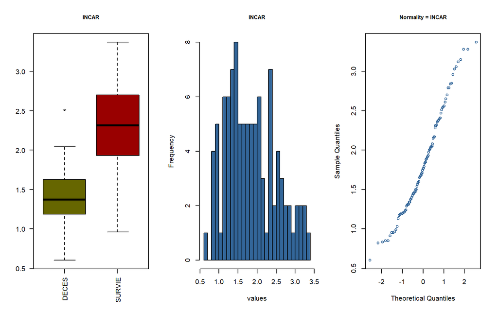

```r
#-> histogrammes , boxplot et qqplot
# ... on n'affiche que quelques histogrammes...
#.... en principe il faudrait réaliser les histogrammes de toutes les variables  !!
i <- 3
#--> palette couleur
 col  <- c('#666600', '#990000', '#0066CC' , '#003366' )
 par(mfrow = c(1,3)) ;
 boxplot(df[,i]~df$PRONO,
         las = 2,
         col = col,
         cex.main = 0.8, main = names(df)[i])
 #-> Histogramme
 hist(df[,i],
         nclass = 30,
         main   = paste0(names(df)[i]) ,
         xlab   = 'values',
         col    = '#336699',
         cex.main = 0.8)
 #-> pplot
 qqnorm(df[,i], col = '#336699', cex = 0.8,
           cex.main = 0.8,
           main = paste0('Normality = ', names(df)[i]))
```

**2.3 Corrélations**

```r
#--> corrélation entre les variables
cor(dfstat)
```

```
##             FRCAR      INCAR      INSYS      PRDIA      PAPUL       PVENT
## FRCAR  1.00000000 -0.1120492 -0.5025332  0.3987538  0.3701207 -0.08546307
## INCAR -0.11204925  1.0000000  0.8871083 -0.3606371 -0.2694218 -0.28196150
## INSYS -0.50253322  0.8871083  1.0000000 -0.4827061 -0.4054714 -0.20123996
## PRDIA  0.39875379 -0.3606371 -0.4827061  1.0000000  0.9278246  0.28466827
## PAPUL  0.37012071 -0.2694218 -0.4054714  0.9278246  1.0000000  0.24419689
## PVENT -0.08546307 -0.2819615 -0.2012400  0.2846683  0.2441969  1.00000000
## REPUL  0.24700425 -0.7669762 -0.7351064  0.7014298  0.6504152  0.25760240
##            REPUL
## FRCAR  0.2470042
## INCAR -0.7669762
## INSYS -0.7351064
## PRDIA  0.7014298
## PAPUL  0.6504152
## PVENT  0.2576024
## REPUL  1.0000000
```

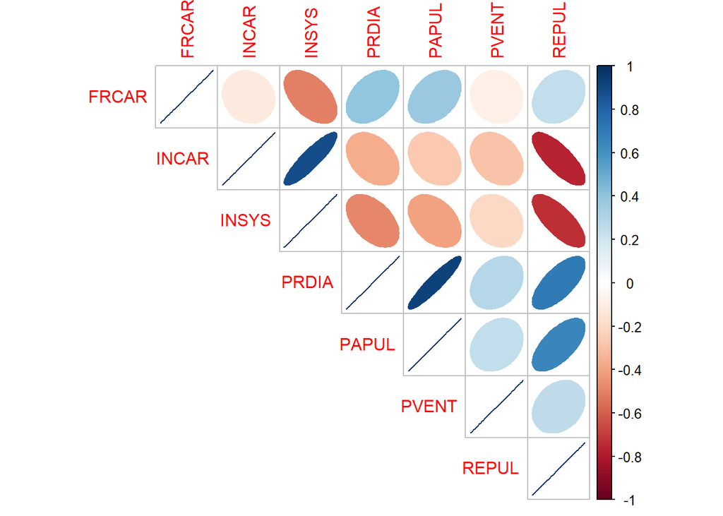

```r
corrplot(cor(dfstat), method = 'ellipse', type = 'upper')
```

*retour au plan*

## ———————————————————

##### **3. Analyse en composante principale**

- L’ACP est une méthode géométrique qui consiste à effectuer des projections sur des axes perpendiculaires des points (observations) tout en préservant au mieux leur distance. Cette dernière reflète la dispersion des points entre eux ce qui équivaut, sous certaines conditions, à une variance.

**3.1 Inertie**

- L’inertie correspond à la part de variance expliquée par un axe factoriel. Elle reflète donc la qualité de la projection et par voie de conséquence ’la part d’information" expliquée par rapport à l’information totale. Avant tout autre calcul en ACP il convient de déterminer les inerties axpliquées par chaque axe.
- L’ACP standard ne peut être réaliser que sur des données continues. Cependant, il est possible d’utiliser la variable pronostique comme variable indicatrice. Etant de nature factorielle; elle ne participe pas aux calculs des axes ni aux calculs des coordonnées des individus et des variables dans les plans factoriels. Cepandant, il est possible de représenter les individux appartenant aux deux groupes dans les plans.
- L’ACP est une méthode souvent employée en amont de l’apprentissage statistique supervisée pour diminuer la dimensionnalité des jeux de données.

```r
# On utilise la fonction PCA du package FactoMineR
#  arguments 1 : data.frame
#              2 : L'acp est très sensible à la métrique utilisée. il est donc impératif de normaliser les données (centrage et réduction) -> scale.unit = T
#              3 ; la première variable de data.frame est une variable de type qualitative (factorielle  dans notre cas)

acp <- PCA(df, scale.unit = T, quali.sup = c(1), graph = F)
# acp est un objet composée d'un ensemble de listes R
inertie <- acp$eig
```

```r
print(inertie)
```

```
##        eigenvalue percentage of variance cumulative percentage of variance
## comp 1 3.78656992             54.0938560                          54.09386
## comp 2 1.22594850             17.5135499                          71.60741
## comp 3 1.09305860             15.6151229                          87.22253
## comp 4 0.65823458              9.4033511                          96.62588
## comp 5 0.14785983              2.1122832                          98.73816
## comp 6 0.06761102              0.9658717                          99.70403
## comp 7 0.02071756              0.2959651                         100.00000
```

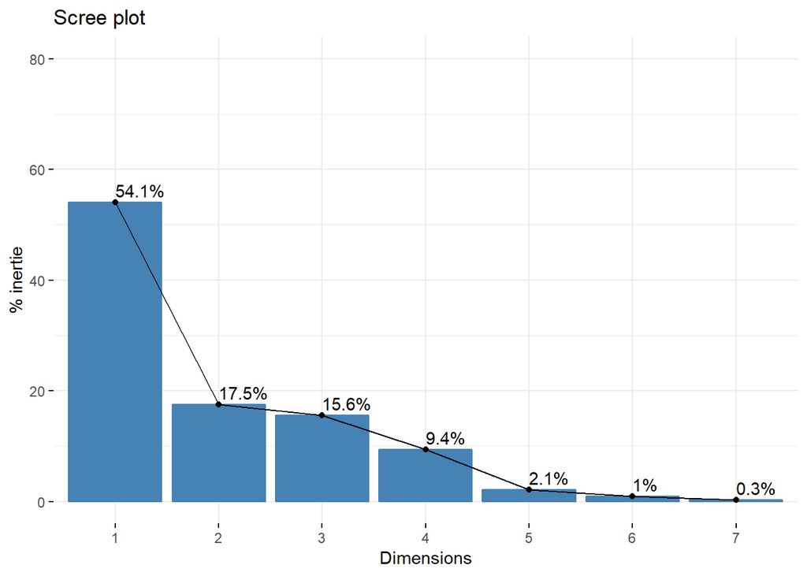

```r
#h est un oobjet graphique de ggplot2. il est donc possible de le modifier et d'ajouter des couches suplémentaires
h <- fviz_eig(acp, addlabels = T, ylim = c(0,80), ylab = c('% inertie'))
print(h)
```

- le tableau et le graphique précédent montrent que les 3 premiers axes principaux expliquent 87% de la dispersion du nuage de points. Autrement dit on reconstruit avec 3 axes 87% de l’information initiale du tableau de données !. On passe donc d’une tableau à 7 variables à un tableau à 3 axes ! avec une perte de 13%. (Il s’agit d’une cas assez rare cependant….)

*retour au plan*

**3.2 Qualité de projection des variables dans le plan 1-2**

- Nous nous intéressons aux projections des variables sur les axes factoriels et à la qualité de ses projections. En étudiant les projections sur les deux premiers axes les valeurs sont les suivantes :
- les coordonnées des variables dans le plan 1-2

```r
acp$var$coord
```

```
##            Dim.1      Dim.2        Dim.3       Dim.4       Dim.5
## FRCAR  0.4767002  0.5249107 -0.500276679  0.48742067  0.08869090
## INCAR -0.7590859  0.5915369  0.218525367  0.09080784  0.09167895
## INSYS -0.8508014  0.2767207  0.393933597 -0.12524382  0.13655610
## PRDIA  0.8382868  0.3971520  0.283961701 -0.12322825 -0.08607342
## PAPUL  0.7819483  0.4685010  0.320141787 -0.16408760 -0.09612206
## PVENT  0.3612291 -0.3510732  0.675765488  0.53697650  0.03455487
## REPUL  0.9025509 -0.1531396  0.007798888 -0.25742937  0.30838130
```

```r
# coordonnées
acp$var$coord[,1:2]
```

```
##            Dim.1      Dim.2
## FRCAR  0.4767002  0.5249107
## INCAR -0.7590859  0.5915369
## INSYS -0.8508014  0.2767207
## PRDIA  0.8382868  0.3971520
## PAPUL  0.7819483  0.4685010
## PVENT  0.3612291 -0.3510732
## REPUL  0.9025509 -0.1531396
```

```r
acp$var$cos2[,1:2]
```

```
##           Dim.1      Dim.2
## FRCAR 0.2272431 0.27553129
## INCAR 0.5762114 0.34991586
## INSYS 0.7238630 0.07657437
## PRDIA 0.7027248 0.15772967
## PAPUL 0.6114431 0.21949316
## PVENT 0.1304865 0.12325240
## REPUL 0.8145981 0.02345174
```

```r
# La qualité de répresantation dans le plan

apply(acp$var$cos2[,1:2],1,sum)
```

```
##     FRCAR     INCAR     INSYS     PRDIA     PAPUL     PVENT     REPUL
## 0.5027744 0.9261272 0.8004373 0.8604545 0.8309363 0.2537389 0.8380498
```

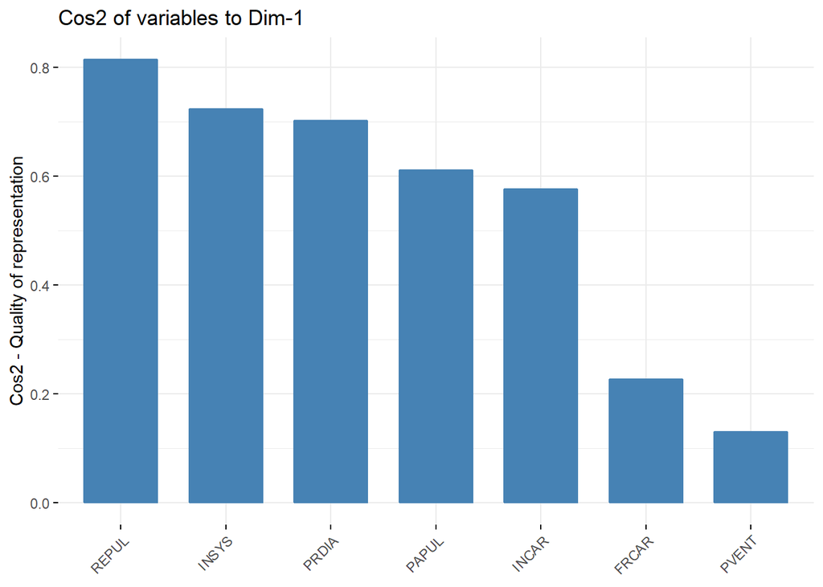

```r
fviz_cos2(acp, choice = "var", axes = 1) # axe 1
```

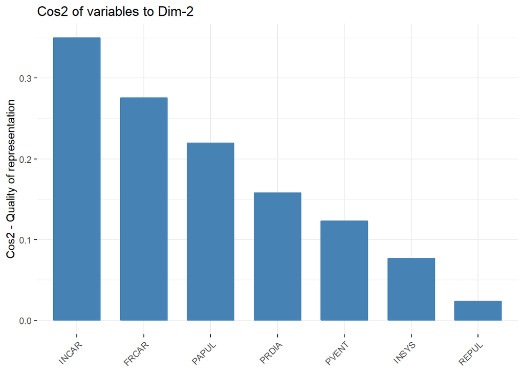

```r
fviz_cos2(acp, choice = "var", axes = 2) # axe 2
```

**3.3 Projection des variables dans le plan 1-2**

- La représentation des variables dans le plan factoriel

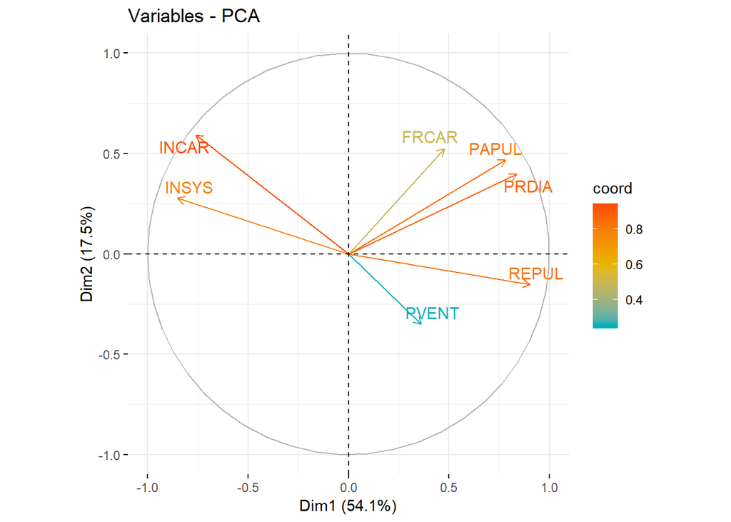

```r
fviz_pca_var(acp, col.var = "coord",
             gradient.cols = c("#00AFBB", "#E7B800", "#FC4E07"),
             repel = TRUE )# Avoid text overlapping
```

*Au total :*

- La qualité de représentation des variables dans le plan est très bonne. En conséquance, le positionnement et la direction des variables l’est aussi.
- Il est possible de représenter l’axe 1 comme dynamique qui oppose deux groupes de variables. INCAR & INSYS versus PAPUL, REPUL, PRDIA

*retour au plan*

**3.4 Projection des individus dans le plan 1-2**

- On s’intéresse maintenant au positionnement des individus dans le plan factoriel 1-2. Les individus de chaque catégorie (vivant, décédé) sont représentés par des couleurs différentes ce qui permet de voir le positionnement de chaque groupe par rapport aux variables ainsi que leur centre de gravité.

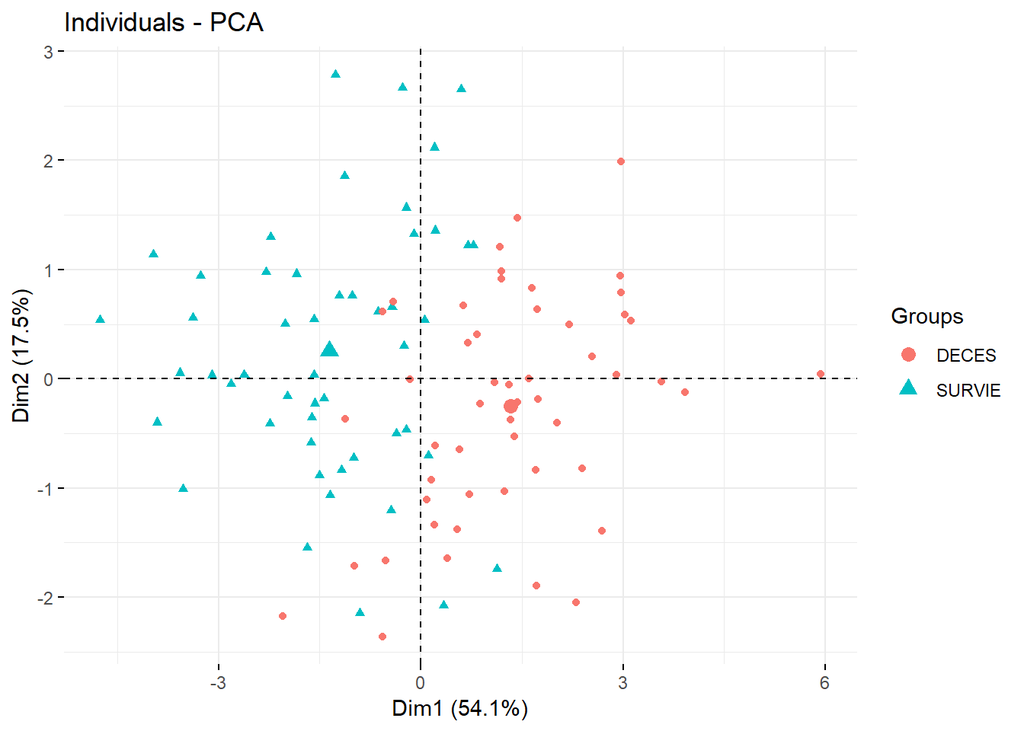

```r
fviz_pca_ind(acp,
             geom.ind = "point",
             col.ind =df$PRONO, # color by groups
             addEllipses = F, # Concentration ellipses
             legend.title = "Groups"
)
```

- Dans le plan factoriel 1-2, la répartition entre les patients vivants et décédés est bien différente. Les coordonnées des points dans le plan pourrait être utilisé pour un apprentissage automatique.

*retour au plan*

**3.5 Biplot et interprétation**

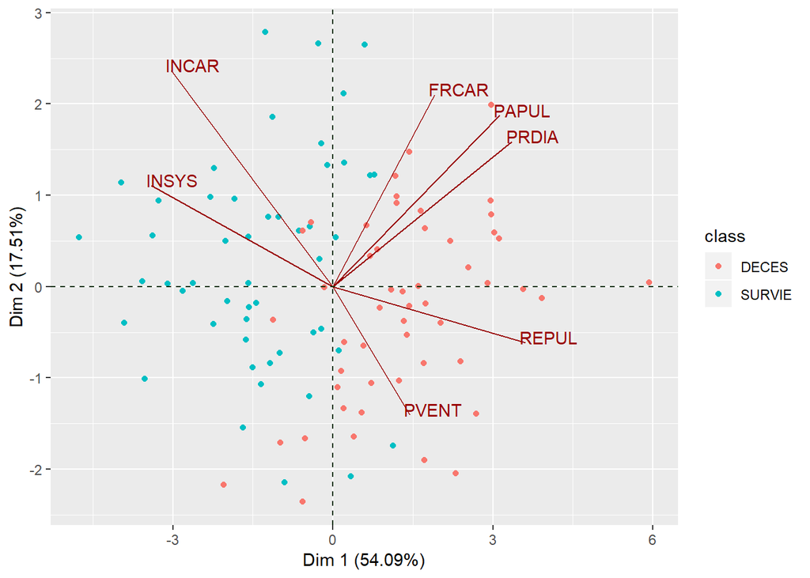

```r
PCA_Biplot = function(pca , df, qualisup = NULL, axes = c(1,2), cos2 = 0, ncp = 7 )
{
  scale <- 4
  varX <- pca$var$coord[,axes[1]]; varcosX =  pca$var$cos2[,axes[1]]
  varY <- pca$var$coord[,axes[2]]; varcosY =  pca$var$cos2[,axes[2]]
  #-> qualité de représentation dans le plan
  cosT <- varcosX + varcosY
  id   <- which(cosT > cos2)
  Vp   <- pca$svd$V[id,axes]
  lam  <- matrix(pca$eig[axes,1],ncol = length(pca$eig[axes,1]), nrow = length(id), byrow = T)
  tab  <- pca$var$coord[id,axes]
  ind  <- data.frame(pca$ind$coor[,axes],'class' = df[,qualisup])
  names(ind) <- c('X','Y', 'class')
  g <- ggplot() + geom_point(data = ind,aes(x = X, y = Y, color = class))
  g <- g + geom_segment(aes(x = rep(0,nrow(tab)), y = rep(0,nrow(tab)), xend = scale*tab[,1],yend = scale*tab[,2]), color = '#990000')
  g <- g + geom_text(aes(x =scale*tab[,1], y = scale*tab[,2]), label = rownames(tab), hjust = 0.1, vjust = 0.1, color = '#990000' )
  g <- g + geom_hline(yintercept = 0, colour = '#003300', linetype = 2 )
  g <- g + geom_vline(xintercept = 0, colour = '#003300', linetype = 2 )
  g <- g + xlab(paste0('Dim ',axes[1] ,' (', round(pca$eig[axes[1],2], digits = 2 ), '%)' ))
  g <- g + ylab(paste0('Dim ',axes[2] ,' (', round(pca$eig[axes[2],2], digits = 2 ), '%)' ))
  n <- colnames(pca$ind$coord[,axes])
   return(g)
}
g <- PCA_Biplot(pca = acp, df = df , qualisup = 1)
print(g)
```

Le biplot met en évidence les points suivants

- les personnes ayant survécues ont des indexs cardiaques et systoliques plus élevés que les personnees décédées.
- les personnes décédées ont une pression artérielle pulomnaire (sang veineux), une pression diastolique (pression au repos), une fréquence cardiaque, une résistance pulmonaire plus élévée que les personnees ayant survécues
- les indexes sont en oppositions sur l’axe 1

D’un point de vue physiologique l’index cardiaque (IPS) permet de suivre l’évolution d’une artériopathie. Une pression diastolique élevée associée à une fréquence cardiaque élevée montre que le coeur fournit un effort très important et se “fatigue vite”. De plus, associée à une résistance pulmonaire, elle conduit à une insuffisance cardiaque droite qui peut conduire au décès si le patient n’est pas pris en charge rapidement.

**En conclusion** **Les méthodes factorielles sont des outils trés puissants. Mais attention à leur utilisation quant à l’interprétation qui doit TOUJOURS être réalisée par un spécialiste du domaine. Le regroupement effectué n’est pas une classification, il s’agit simplement d’une aide à l’interprétation et à la représentation qui permet dans certain cas, une diminution de la dimmensionalité des données pour réaliser un apprentissage supervisé (avec conservation maximale de la variance c.a.d de la dispersion du nuage initiale de point et la qualité de l’information initiale)**

*retour au plan*

## ———————————————————

##### **4. Classification ascendente**

** 4.1 Classification sur les données initiales**

Nous allons dans un premier temps effectuer une classification sur les données initiales (comprenant 7 variables-attributs numériques).

- Les données du data frame sont centrées,
- Nous choisissons comme métrique la distance euclidienne,
- nous choisissons le critère d’aggégation de Ward.

Ce paramètrage est le plus général et le plus utilisé. il est important de rappeler que le choix de la métrique et du critère d’aggrégation peut induire des variations très importantes des regroupements et donc de la classification.

**4.1 Classification ascendantes sur les données initales**

```r
  # transformation de la variable catègorielle en nom des Instances
  #--> Centrage des données SANS REDUCTION
  df.stand <- scale(df[2:8], scale = F)
  row.names(df.stand) <- df$PRONO
  #--> calcul des distances euclidiennes entre les attribust (variables)
  df.dist  <- dist(df.stand,method = "euclidean")
  #-->  Attention, l'objer df.dist n'est pas une matrice, il faut donc le convertir
  df.dis.mat <- as.matrix(df.dist)
  #--> On effectue la classification
  df.cah <- hclust(df.dist,method = 'ward.D') ; print(df.cah)
```

```
##
## Call:
## hclust(d = df.dist, method = "ward.D")
##
## Cluster method   : ward.D
## Distance         : euclidean
## Number of objects: 101
```

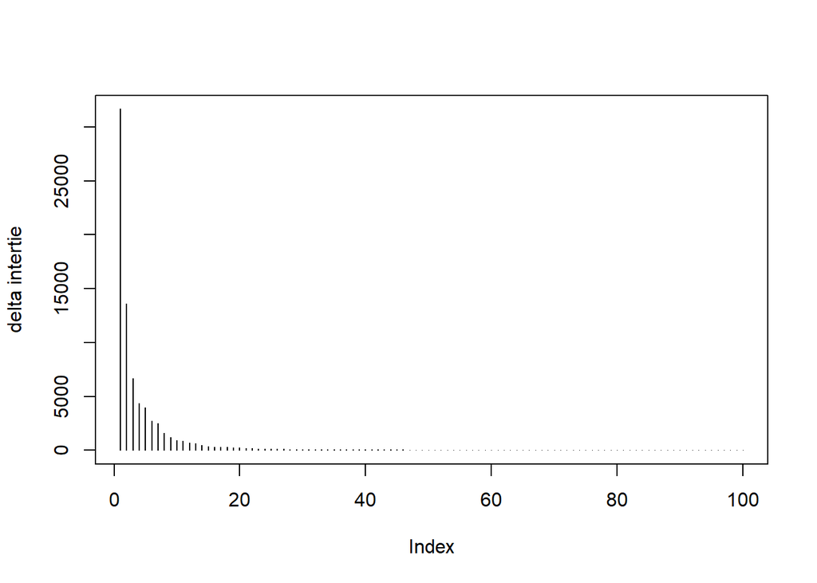

```r
  #--> Sélection du nombre de classe
  plot(rev(df.cah$height), type = 'h', ylab = 'delta intertie')
```

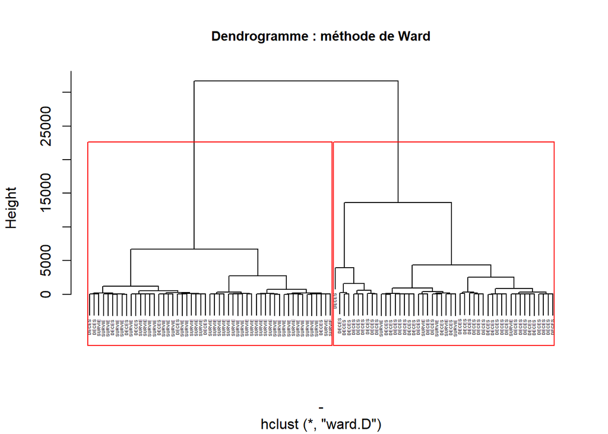

```r
  #-> Dendrogramme
  nk <- 2
  plot(df.cah, main = 'Dendrogramme : méthode de Ward',cex.main = 0.9, xlab = " - ",cex = 0.3, horiz = F )
  #--> Sélection du nombre de classe
  rect.hclust(df.cah,k = nk)
```

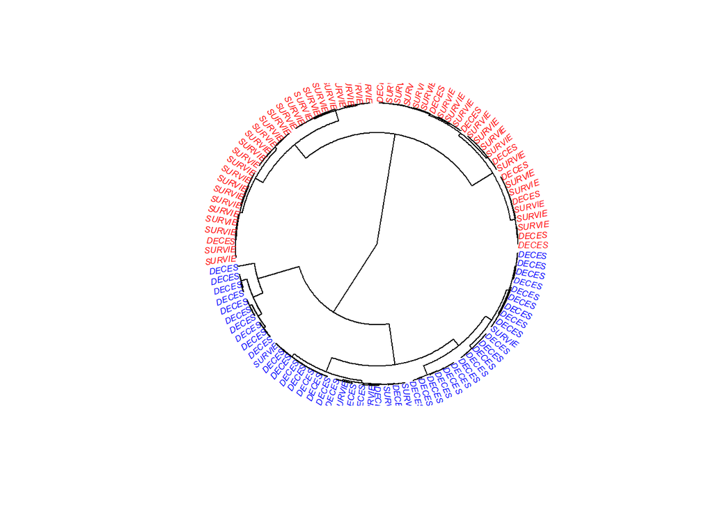

```r
   #-> visualisation sous forme d'arbre phylogénique
  colors = c("red", "blue", "green", "black")
  clus4 = cutree(df.cah, 2)
  plot(as.phylo(df.cah), type = "fan", tip.color = colors[clus4], label.offset = 2, cex = 0.5)
```

```r
  #-> retourne la partition de la CAH
  d <- cutree(df.cah,k=nk)
  #-> matrice des confusions
  gold <- factor(df$PRONO)
  pred <- factor(d,levels = c(2,1), labels =c('DECES','SURVIE'))
  confusionMatrix(pred,gold)
```

```
## Confusion Matrix and Statistics
##
##           Reference
## Prediction DECES SURVIE
##     DECES     42      6
##     SURVIE     9     44
##
##                Accuracy : 0.8515
##                  95% CI : (0.7669, 0.9144)
##     No Information Rate : 0.505
##     P-Value [Acc > NIR] : 2.852e-13
##
##                   Kappa : 0.7031
##  Mcnemar's Test P-Value : 0.6056
##
##             Sensitivity : 0.8235
##             Specificity : 0.8800
##          Pos Pred Value : 0.8750
##          Neg Pred Value : 0.8302
##              Prevalence : 0.5050
##          Detection Rate : 0.4158
##    Detection Prevalence : 0.4752
##       Balanced Accuracy : 0.8518
##
##        'Positive' Class : DECES
##
```

- la caractérisation des groupes par CAH est bonne avec une Exactitude de 85% sur les donnéss initiales (k = 2). Attention, il ne s’agit pas d’une méthode supervisée. En effet, il n’y a aucun critère de classification ni de régression à minimiser

*retour au plan*

**4.2 Classification ascendantes sur les données d’ACP**

*a. Approche standard*

- on réitère les séquences précédentes avec les coordonnées des individus dans le plan factoriel 1-2

```r
  df.acp <- acp$ind$coord[,1:2]
  row.names(df.acp) <- df$PRONO
  #--> calcul des distances euclidiennes entre les attribust (variables)
  df.dist  <- dist(df.acp,method = "euclidean")
  #-->  Attention, l'objer df.dist n'est pas une matrice, il faut donc le convertir
  df.dis.mat <- as.matrix(df.dist)
  #--> On effectue la classification
  df.cahacp <- hclust(df.dist,method = 'ward.D') ; print(df.cah)
```

```
##
## Call:
## hclust(d = df.dist, method = "ward.D")
##
## Cluster method   : ward.D
## Distance         : euclidean
## Number of objects: 101
```

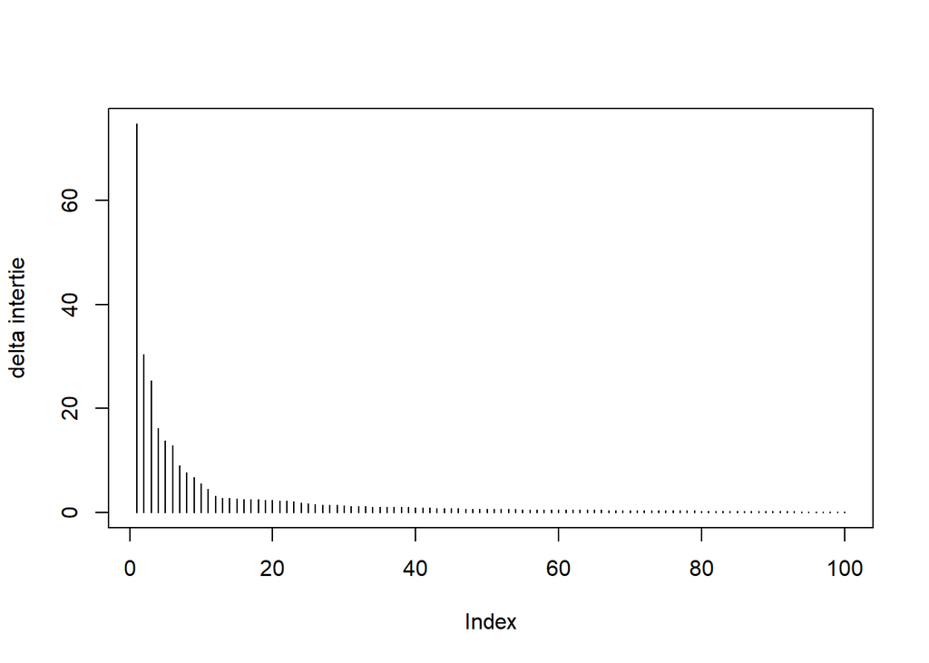

```r
  #--> Sélection du nombre de classe
  plot(rev(df.cahacp$height), type = 'h', ylab = 'delta intertie')
```

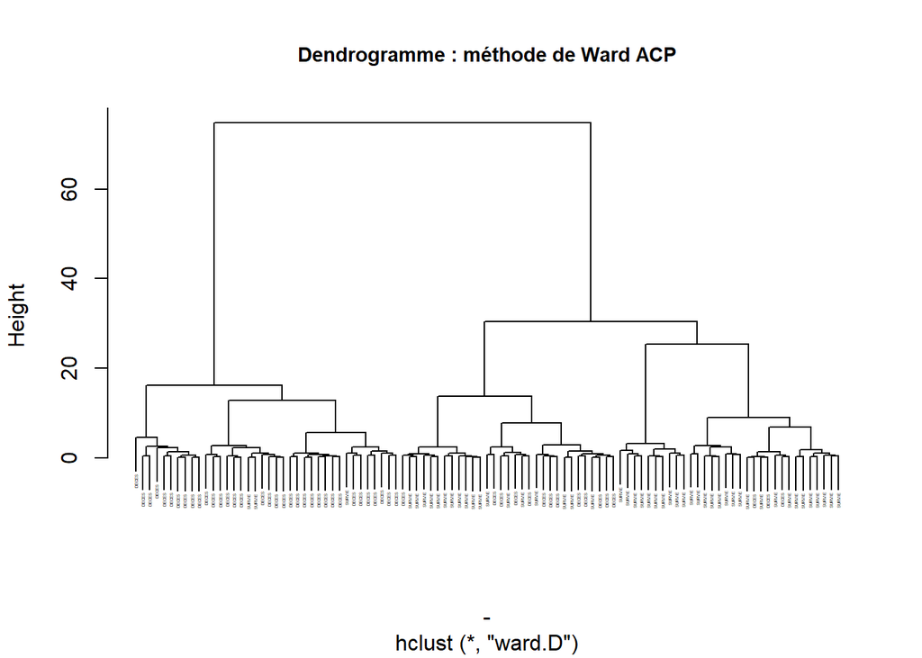

```r
  #-> Dendrogramme
  nk <- 2
  plot(df.cahacp, main = 'Dendrogramme : méthode de Ward ACP',cex.main = 0.9, xlab = " - ",cex = 0.2 )
```

```r
  cut <- cutree(df.cahacp,k=nk)

  #-> matrice des confusions
  gold <- factor(df$PRONO)
  pred <- factor(cut,levels = c(2,1), labels =c('DECES','SURVIE'))
  confusionMatrix(pred,gold)
```

```
## Confusion Matrix and Statistics
##
##           Reference
## Prediction DECES SURVIE
##     DECES     35      3
##     SURVIE    16     47
##
##                Accuracy : 0.8119
##                  95% CI : (0.7219, 0.8828)
##     No Information Rate : 0.505
##     P-Value [Acc > NIR] : 1.549e-10
##
##                   Kappa : 0.6247
##  Mcnemar's Test P-Value : 0.005905
##
##             Sensitivity : 0.6863
##             Specificity : 0.9400
##          Pos Pred Value : 0.9211
##          Neg Pred Value : 0.7460
##              Prevalence : 0.5050
##          Detection Rate : 0.3465
##    Detection Prevalence : 0.3762
##       Balanced Accuracy : 0.8131
##
##        'Positive' Class : DECES
##
```

*retour au plan*

*b. On utilise la fonction HCPC du package FactomineR avec toutes les variables*

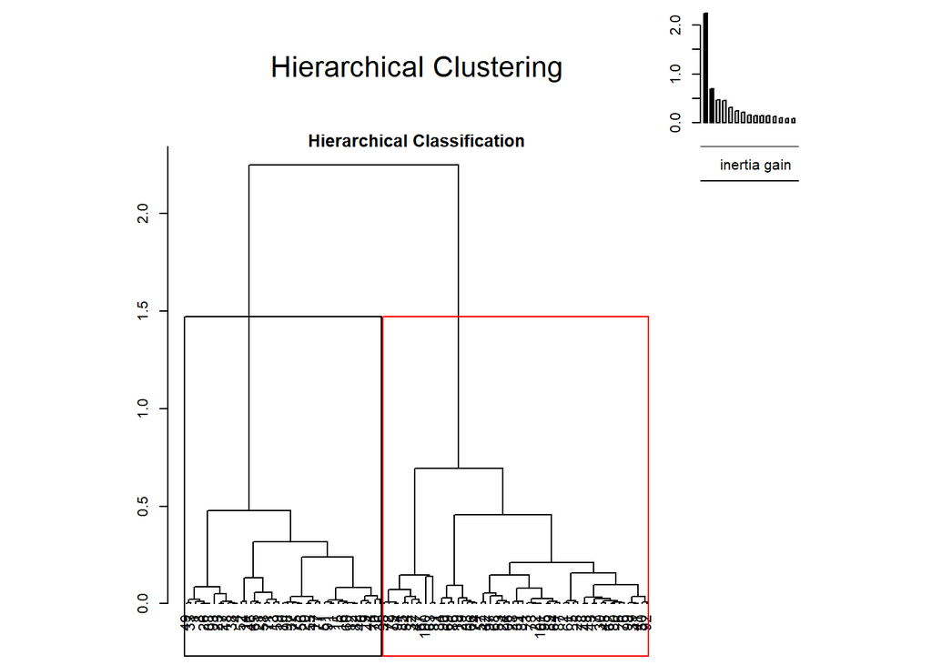

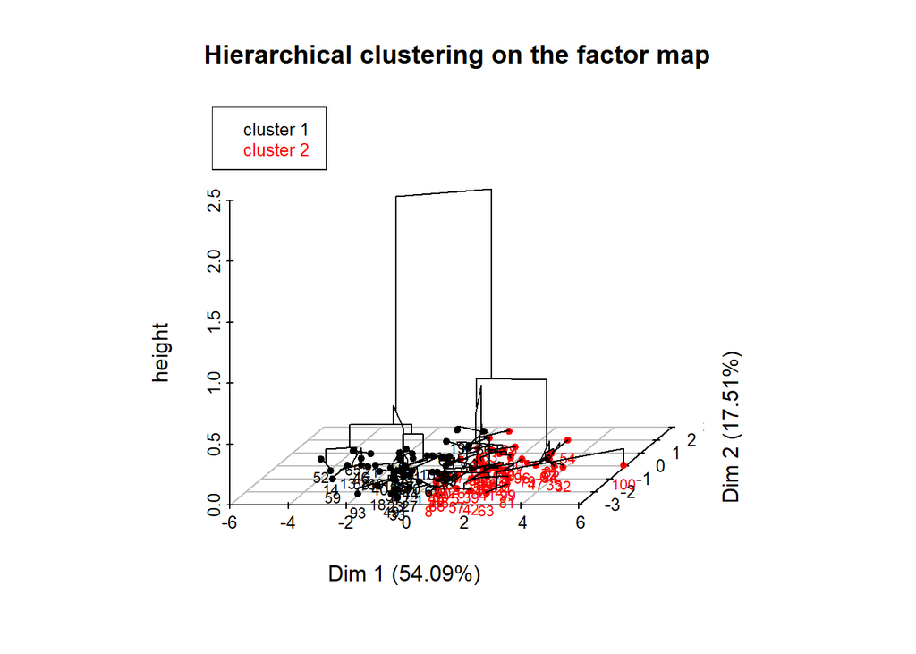

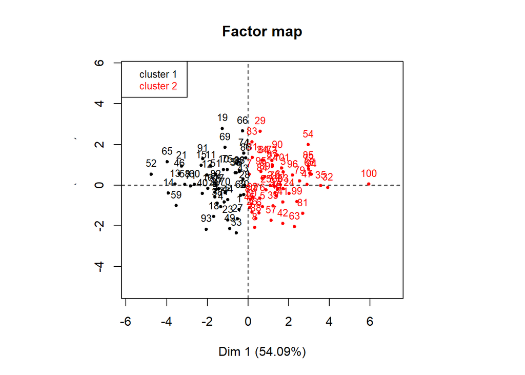

```r
res.cah = HCPC(acp, graph=T, nb.clust = 2)
```

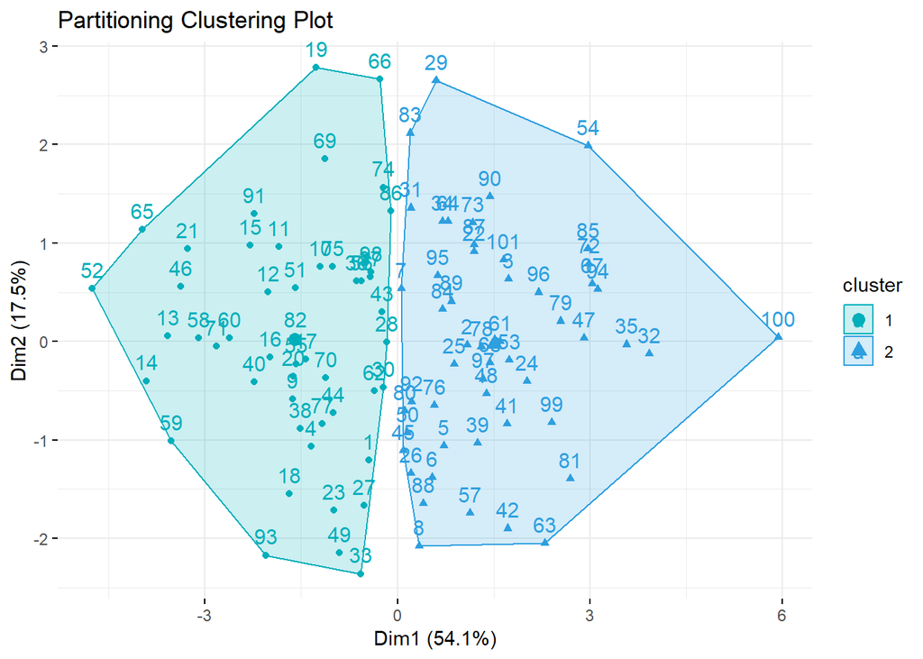

```r
#-> autre visualisation
fviz_cluster(res.cah, data = df,
             palette = c("#00AFBB","#2E9FDF", "#E7B800", "#FC4E07"),
             ggtheme = theme_minimal(),
             main = "Partitioning Clustering Plot"
             )
```

```r
#-> Matrice des confusions
predacp <- factor(res.cah$data.clust[,9], levels = c(2,1), labels= c('DECES','SURVIE'))
confusionMatrix(predacp,gold)
```

```
## Confusion Matrix and Statistics
##
##           Reference
## Prediction DECES SURVIE
##     DECES     43      9
##     SURVIE     8     41
##
##                Accuracy : 0.8317
##                  95% CI : (0.7442, 0.8988)
##     No Information Rate : 0.505
##     P-Value [Acc > NIR] : 7.621e-12
##
##                   Kappa : 0.6633
##  Mcnemar's Test P-Value : 1
##
##             Sensitivity : 0.8431
##             Specificity : 0.8200
##          Pos Pred Value : 0.8269
##          Neg Pred Value : 0.8367
##              Prevalence : 0.5050
##          Detection Rate : 0.4257
##    Detection Prevalence : 0.5149
##       Balanced Accuracy : 0.8316
##
##        'Positive' Class : DECES
##
```

*retour au plan*

**3.3 Comparaison des différentes approches**

Les resultats sont les suivants.

- sur les données initiales : Exactitude = 85% ; FP = 9% ; FN = 6%
- sur les deux premiers axes en ACP : Exactitude = 81% ; FP = 16% ; FN = 3%
- sur les deux premiers axes en FactomineR : Exactitude = 83% ; FP = 8% ; FN = 9%
- Concernant **L’exactidude**, elle est correcte pour les 3 méthodes. Dans notre cas, Si l’on ne s’intéresse qu’à ce paramètre, les 3 méthodes sont équivalentes et > à 80%. La CAH sur les deux premiers axes princaux fournit des résultats similaires (81% vs 83% , 85% ) avec une diminution notable de la dimmensionnalité (de 7 à deux variables). Par contre, si l’on s’intéresse aux taux de FP et FN, cette méthode ne doit plus être utilisée. Dans le domaine de la Santé, il est souvent plus important de se focaliser les FP et le FN !!
- Concernant **Les taux de FP et FN**, il y a des différences importantes, Ayant éliminer la seconde méthode (FP = 16%), le choix entre les deux autres méthodes se fera en fonction des objectifs de l’étude et des contraintes associées.

*retour au plan*

## ———————————————————

##### **5. Moyenne Mobile**

** 5.1 Classification sur les données initiales**

```r
df.mob       <- kmeans(df.stand,centers = nk, nstart = 9)
d            <- df.mob$cluster
gold         <- factor(df$PRONO)
pred         <- factor(d,levels = c(1,2), labels =c('DECES','SURVIE'))
confusionMatrix(pred,gold)
```

```
## Confusion Matrix and Statistics
##
##           Reference
## Prediction DECES SURVIE
##     DECES     16      0
##     SURVIE    35     50
##
##                Accuracy : 0.6535
##                  95% CI : (0.5523, 0.7454)
##     No Information Rate : 0.505
##     P-Value [Acc > NIR] : 0.001829
##
##                   Kappa : 0.3116
##  Mcnemar's Test P-Value : 9.081e-09
##
##             Sensitivity : 0.3137
##             Specificity : 1.0000
##          Pos Pred Value : 1.0000
##          Neg Pred Value : 0.5882
##              Prevalence : 0.5050
##          Detection Rate : 0.1584
##    Detection Prevalence : 0.1584
##       Balanced Accuracy : 0.6569
##
##        'Positive' Class : DECES
##
```

**5.2 Moyenne mobile sur les données d’ACP**

- on réitère les séquences précédentes avec les coordonnées des individus dans le plan factoriel 1-2

```r
df.mob.acp       <- kmeans(acp$ind$coord[,1:2],centers = nk, nstart = 9)
d.mob.acp        <- df.mob.acp$cluster
pred             <-factor(d.mob.acp, levels = c(1,2), labels =c('DECES','SURVIE'))
gold             <- factor(df$PRONO)
confusionMatrix(pred,gold)
```

```
## Confusion Matrix and Statistics
##
##           Reference
## Prediction DECES SURVIE
##     DECES     43      9
##     SURVIE     8     41
##
##                Accuracy : 0.8317
##                  95% CI : (0.7442, 0.8988)
##     No Information Rate : 0.505
##     P-Value [Acc > NIR] : 7.621e-12
##
##                   Kappa : 0.6633
##  Mcnemar's Test P-Value : 1
##
##             Sensitivity : 0.8431
##             Specificity : 0.8200
##          Pos Pred Value : 0.8269
##          Neg Pred Value : 0.8367
##              Prevalence : 0.5050
##          Detection Rate : 0.4257
##    Detection Prevalence : 0.5149
##       Balanced Accuracy : 0.8316
##
##        'Positive' Class : DECES
##
```

*retour au plan*

**5.3 Comparaison des différentes approches**

- Contrairement à l’analyse par CAH, les resultats sont bien meilleurs lorque nous effectuons un k-mean sur les données projetées dans la plan 1-2. Cependant, il ne faut pas trop s’y fier. En effet, les résultats obtenus par les K-mean sont très sensibles aux centres de gravité choisis initialement (au hasard !!) et aux données “abhérantes” ! En générale, les deux méthodes sont réalisées l’une à la suite de l’autre. Dans un premier temps, on effectue plusieurs K-mean avec des centres de gravité initiaux différents puis, on réalise une CAH. c’est exactement ce fait la fonction HCPC de FactomineR !